# Biostat 203B Homework 3

Due Feb 23 @ 11:59PM

Author

Yanzi Sun 106183069

Load necessary libraries (you can add more as needed).

```r
library(arrow)
library(gtsummary)
library(memuse)
library(pryr)
library(R.utils)
library(tidyverse)
library(ggplot2)
```

Display your machine memory.

```r
memuse::Sys.meminfo()
```

```
Totalram:   16.000 GiB
Freeram:   160.641 MiB
```

In this exercise, we use tidyverse (ggplot2, dplyr, etc) to explore the [MIMIC-IV](https://physionet.org/content/mimiciv/3.1/) data introduced in [homework 1](https://ucla-biostat-203b.github.io/2025winter/hw/hw1/hw1.html) and to build a cohort of ICU stays.

## Q1. Visualizing patient trajectory

Visualizing a patient’s encounters in a health care system is a common task in clinical data analysis. In this question, we will visualize a patient’s ADT (admission-discharge-transfer) history and ICU vitals in the MIMIC-IV data.

### Q1.1 ADT history

A patient’s ADT history records the time of admission, discharge, and transfer in the hospital. This figure shows the ADT history of the patient with `subject_id` 10001217 in the MIMIC-IV data. The x-axis is the calendar time, and the y-axis is the type of event (ADT, lab, procedure). The color of the line segment represents the care unit. The size of the line segment represents whether the care unit is an ICU/CCU. The crosses represent lab events, and the shape of the dots represents the type of procedure. The title of the figure shows the patient’s demographic information and the subtitle shows top 3 diagnoses.

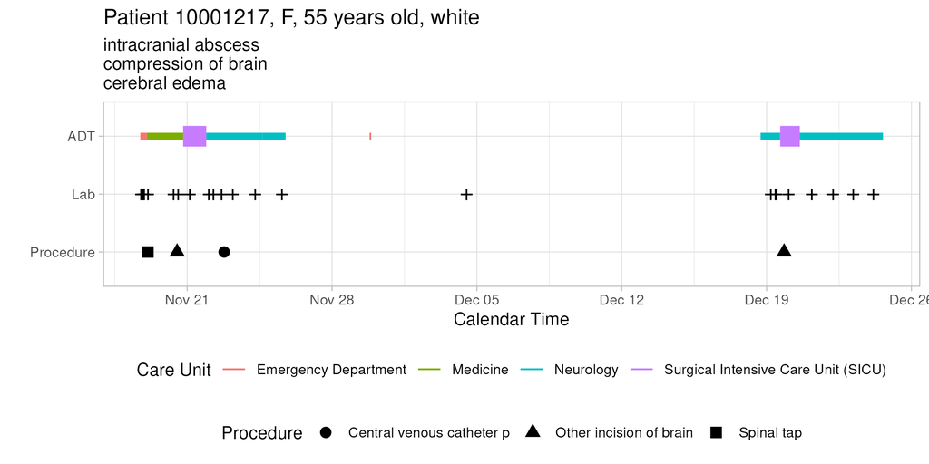

Do a similar visualization for the patient with `subject_id` 10063848 using ggplot.

Hint: We need to pull information from data files `patients.csv.gz`, `admissions.csv.gz`, `transfers.csv.gz`, `labevents.csv.gz`, `procedures_icd.csv.gz`, `diagnoses_icd.csv.gz`, `d_icd_procedures.csv.gz`, and `d_icd_diagnoses.csv.gz`. For the big file `labevents.csv.gz`, use the Parquet format you generated in Homework 2. For reproducibility, make the Parquet folder `labevents_pq` available at the current working directory `hw3`, for example, by a symbolic link. Make your code reproducible.

**Solution:** My result is shown below.

```r
#use semi-join to filter & merge rows
labevents_pq <- arrow::open_dataset("labevents_parquet",
                                         format = "parquet") %>%
              filter(subject_id == 10063848) %>%
              collect()
```

```r
#pulled data from&creating subjects patients_df, `admissions.csv.gz`, `transfers.csv.gz`, `labevents.csv.gz`, `procedures_icd.csv.gz`, `diagnoses_icd.csv.gz`, `d_icd_procedures.csv.gz`, and `d_icd_diagnoses.csv.gz`.

patients_df <- read_csv("~/mimic/hosp/patients.csv.gz") |>
              filter(subject_id == 10063848) %>%
              collect()
admissions_df <- read_csv("~/mimic/hosp/admissions.csv.gz") |>
              filter(subject_id == 10063848) %>%
              collect()
transfers_df <- read_csv("~/mimic/hosp/transfers.csv.gz") |>
              filter(subject_id == 10063848) %>%
              collect()
procedures_icd_df <- read_csv("~/mimic/hosp/procedures_icd.csv.gz") |>
              filter(subject_id == 10063848) %>%
              collect()
diagnoses_icd_df <- read_csv("~/mimic/hosp/diagnoses_icd.csv.gz") |>
              filter(subject_id == 10063848) %>%
              collect()
d_icd_procedures_df <- read_csv("~/mimic/hosp/d_icd_procedures.csv.gz")
d_icd_diagnoses_df <- read_csv("~/mimic/hosp/d_icd_diagnoses.csv.gz")
```

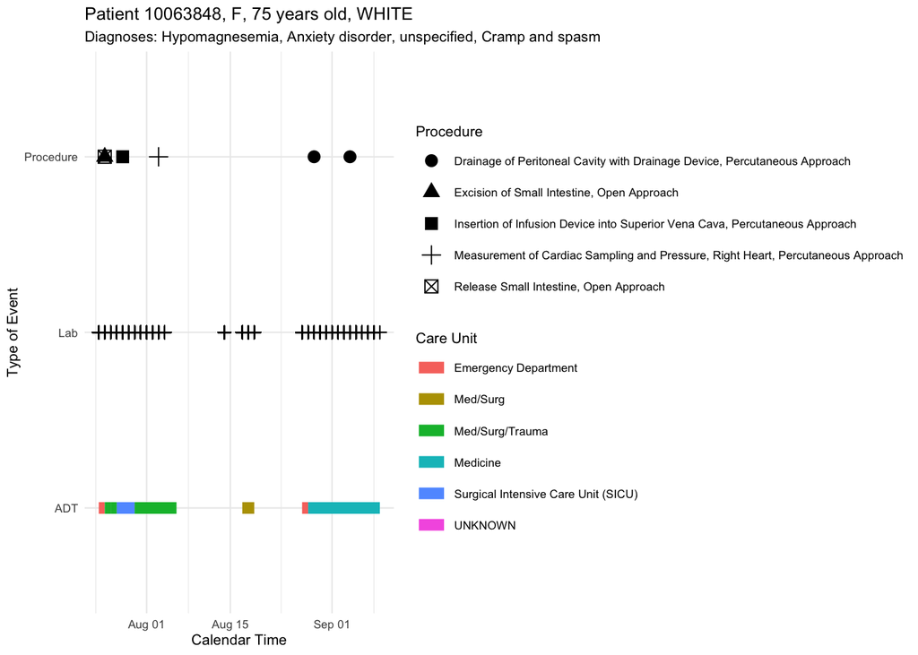

```r
# Load necessary libraries
library(tidyverse)
library(lubridate)

# Convert date columns to Date format
transfers_data <- transfers_df |>
  mutate(intime = as.Date(intime), outtime = as.Date(outtime))

lab_data <- labevents_pq |>
  mutate(charttime = as.Date(charttime))

procedure_data <- procedures_icd_df |>
  mutate(chartdate = as.Date(chartdate))

diagnoses_translated <- diagnoses_icd_df |>
  left_join(d_icd_diagnoses_df, by = "icd_code") |>
  filter(icd_version.y == "10")  |>
  top_n(3, wt = seq_num)  # Select top 3 diagnoses
# Convert to a readable format
diagnoses_text <- paste(diagnoses_translated$long_title,
                        collapse = ", ")

# Merge procedures with descriptions
procedures_translated <- procedure_data  |>
  left_join(d_icd_procedures_df, by = "icd_code")

# Ensure procedure titles are available
procedure_data <- procedure_data  |>
  left_join(d_icd_procedures_df, by = "icd_code")

# Create ggplot visualization
ggplot() +
  # Plot Transfers (Care Units) as segments
  geom_segment(data = transfers_data,
               aes(x = intime, xend = outtime,
                   y = "ADT", yend = "ADT", color = careunit),
               size = 3) +

  # Plot Lab Events as points
  geom_point(data = lab_data,
             aes(x = charttime, y = "Lab"),
             shape = 3, size = 2) +

  # Plot Procedures as points with different shapes
  geom_point(data = procedure_data,
             aes(x = chartdate, y = "Procedure", shape = long_title),
             size = 3, fill = "black") +

  # Formatting
  labs(
    title = paste0("Patient ", patients_df$subject_id,
                   ", ", patients_df$gender, ", ",
                   patients_df$anchor_age, " years old, ",
                   admissions_df$race),
    subtitle = paste("Diagnoses:",
                     paste(diagnoses_text, collapse="\n")),
    x = "Calendar Time", y = "Type of Event",
    color = "Care Unit",
    shape = "Procedure"
  ) +
  scale_x_date(date_labels = "%b %d") +
  theme_minimal(base_size=8)
```

### Q1.2 ICU stays

ICU stays are a subset of ADT history. This figure shows the vitals of the patient `10001217` during ICU stays. The x-axis is the calendar time, and the y-axis is the value of the vital. The color of the line represents the type of vital. The facet grid shows the abbreviation of the vital and the stay ID.

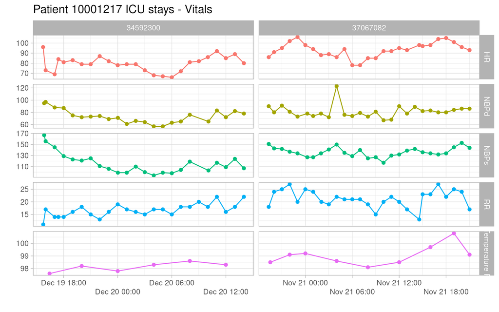

Do a similar visualization for the patient `10063848`.

**Solution:** My work is shown below.

```r
#ingest all icu data
chartevents_pq <- arrow::open_dataset("chartevents_parquet",
                                         format = "parquet") |>
              filter(subject_id == 10063848,
                     itemid %in% c(220045, 220179, 223761, 220210)) |>
              collect()
d_items_df <- read_csv("~/mimic/icu/d_items.csv.gz") |>
            select(itemid, abbreviation)
icu_all <- chartevents_pq |>
          left_join(y=d_items_df, by="itemid") |>
          select(subject_id, stay_id, charttime,
                 itemid, valuenum, abbreviation)
```

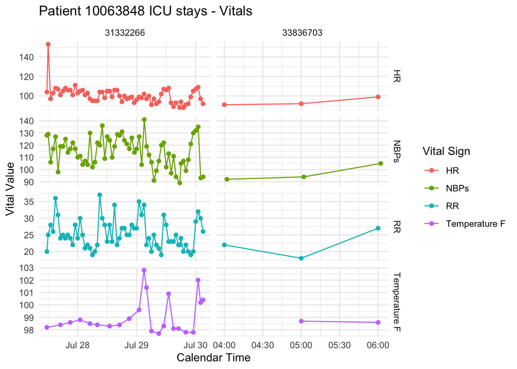

```r
#I consulted with Bowen on this question and he said my computer may read time differently so the second stay could show a different time period.
ggplot(icu_all, aes(x = charttime, y = valuenum, color = abbreviation )) +
  geom_line() +
  geom_point() +
  facet_grid(abbreviation ~ stay_id, scales = "free") +
  scale_x_datetime() +

  # Formatting
  labs(
    title = paste("Patient", "10063848", "ICU stays - Vitals"),
    x = "Calendar Time",
    y = "Vital Value",
    color = "Vital Sign"
  ) +

  # Improve theme aesthetics
  theme_minimal()
```

```r
graphics.off()  # Closes all open plots
rm(list = ls()) # Clears all objects in the environment
gc()            # Runs garbage collection
```

```
          used (Mb) gc trigger  (Mb) limit (Mb) max used  (Mb)
Ncells 1825690 97.6    4171462 222.8         NA  4171462 222.8
Vcells 3422596 26.2   30398439 232.0      16384 47487610 362.4
```

## Q2. ICU stays

`icustays.csv.gz` (https://mimic.mit.edu/docs/iv/modules/icu/icustays/) contains data about Intensive Care Units (ICU) stays. The first 10 lines are

```bash
zcat < ~/mimic/icu/icustays.csv.gz | head
```

```
subject_id,hadm_id,stay_id,first_careunit,last_careunit,intime,outtime,los
10000032,29079034,39553978,Medical Intensive Care Unit (MICU),Medical Intensive Care Unit (MICU),2180-07-23 14:00:00,2180-07-23 23:50:47,0.4102662037037037
10000690,25860671,37081114,Medical Intensive Care Unit (MICU),Medical Intensive Care Unit (MICU),2150-11-02 19:37:00,2150-11-06 17:03:17,3.8932523148148146
10000980,26913865,39765666,Medical Intensive Care Unit (MICU),Medical Intensive Care Unit (MICU),2189-06-27 08:42:00,2189-06-27 20:38:27,0.4975347222222222
10001217,24597018,37067082,Surgical Intensive Care Unit (SICU),Surgical Intensive Care Unit (SICU),2157-11-20 19:18:02,2157-11-21 22:08:00,1.1180324074074075
10001217,27703517,34592300,Surgical Intensive Care Unit (SICU),Surgical Intensive Care Unit (SICU),2157-12-19 15:42:24,2157-12-20 14:27:41,0.948113425925926
10001725,25563031,31205490,Medical/Surgical Intensive Care Unit (MICU/SICU),Medical/Surgical Intensive Care Unit (MICU/SICU),2110-04-11 15:52:22,2110-04-12 23:59:56,1.338587962962963
10001843,26133978,39698942,Medical/Surgical Intensive Care Unit (MICU/SICU),Medical/Surgical Intensive Care Unit (MICU/SICU),2134-12-05 18:50:03,2134-12-06 14:38:26,0.8252662037037037
10001884,26184834,37510196,Medical Intensive Care Unit (MICU),Medical Intensive Care Unit (MICU),2131-01-11 04:20:05,2131-01-20 08:27:30,9.17181712962963
10002013,23581541,39060235,Cardiac Vascular Intensive Care Unit (CVICU),Cardiac Vascular Intensive Care Unit (CVICU),2160-05-18 10:00:53,2160-05-19 17:33:33,1.314351851851852
```

### Q2.1 Ingestion

Import `icustays.csv.gz` as a tibble `icustays_tble`.

```r
icustays_tble <- read_csv("~/mimic/icu/icustays.csv.gz")
```

### Q2.2 Summary and visualization

How many unique `subject_id`? Can a `subject_id` have multiple ICU stays? Summarize the number of ICU stays per `subject_id` by graphs.

**Solution:** There are 65366 unique subject_id. Yes, a subject_id can have multiple icu stays as question 1 shows. The graph of #icu stays per subject_id is shown below.

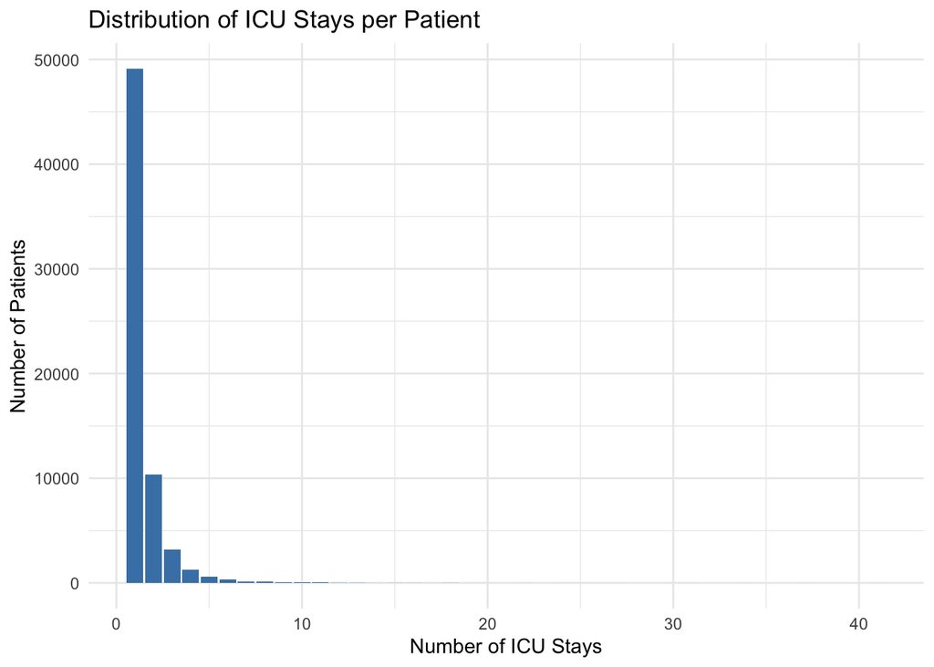

```r
icu_stay_counts <- icustays_tble %>%
  group_by(subject_id) %>%
  summarise(num_stays = n())

stay_distribution <- icu_stay_counts %>%
  group_by(num_stays) %>%
  summarise(frequency = n())

# Create bar plot
ggplot(stay_distribution, aes(x = num_stays, y = frequency)) +
  geom_bar(stat = "identity", fill = "steelblue") +
  labs(
    title = "Distribution of ICU Stays per Patient",
    x = "Number of ICU Stays",
    y = "Number of Patients"
  ) +
  theme_minimal()
```

## Q3. `admissions` data

Information of the patients admitted into hospital is available in `admissions.csv.gz`. See https://mimic.mit.edu/docs/iv/modules/hosp/admissions/ for details of each field in this file. The first 10 lines are

```bash
zcat < ~/mimic/hosp/admissions.csv.gz | head
```

```
subject_id,hadm_id,admittime,dischtime,deathtime,admission_type,admit_provider_id,admission_location,discharge_location,insurance,language,marital_status,race,edregtime,edouttime,hospital_expire_flag
10000032,22595853,2180-05-06 22:23:00,2180-05-07 17:15:00,,URGENT,P49AFC,TRANSFER FROM HOSPITAL,HOME,Medicaid,English,WIDOWED,WHITE,2180-05-06 19:17:00,2180-05-06 23:30:00,0
10000032,22841357,2180-06-26 18:27:00,2180-06-27 18:49:00,,EW EMER.,P784FA,EMERGENCY ROOM,HOME,Medicaid,English,WIDOWED,WHITE,2180-06-26 15:54:00,2180-06-26 21:31:00,0
10000032,25742920,2180-08-05 23:44:00,2180-08-07 17:50:00,,EW EMER.,P19UTS,EMERGENCY ROOM,HOSPICE,Medicaid,English,WIDOWED,WHITE,2180-08-05 20:58:00,2180-08-06 01:44:00,0
10000032,29079034,2180-07-23 12:35:00,2180-07-25 17:55:00,,EW EMER.,P06OTX,EMERGENCY ROOM,HOME,Medicaid,English,WIDOWED,WHITE,2180-07-23 05:54:00,2180-07-23 14:00:00,0
10000068,25022803,2160-03-03 23:16:00,2160-03-04 06:26:00,,EU OBSERVATION,P39NWO,EMERGENCY ROOM,,,English,SINGLE,WHITE,2160-03-03 21:55:00,2160-03-04 06:26:00,0
10000084,23052089,2160-11-21 01:56:00,2160-11-25 14:52:00,,EW EMER.,P42H7G,WALK-IN/SELF REFERRAL,HOME HEALTH CARE,Medicare,English,MARRIED,WHITE,2160-11-20 20:36:00,2160-11-21 03:20:00,0
10000084,29888819,2160-12-28 05:11:00,2160-12-28 16:07:00,,EU OBSERVATION,P35NE4,PHYSICIAN REFERRAL,,Medicare,English,MARRIED,WHITE,2160-12-27 18:32:00,2160-12-28 16:07:00,0
10000108,27250926,2163-09-27 23:17:00,2163-09-28 09:04:00,,EU OBSERVATION,P40JML,EMERGENCY ROOM,,,English,SINGLE,WHITE,2163-09-27 16:18:00,2163-09-28 09:04:00,0
10000117,22927623,2181-11-15 02:05:00,2181-11-15 14:52:00,,EU OBSERVATION,P47EY8,EMERGENCY ROOM,,Medicaid,English,DIVORCED,WHITE,2181-11-14 21:51:00,2181-11-15 09:57:00,0
```

### Q3.1 Ingestion

Import `admissions.csv.gz` as a tibble `admissions_tble`.

```r
admissions_tble <- read_csv("~/mimic/hosp/admissions.csv.gz")
```

### Q3.2 Summary and visualization

Summarize the following information by graphics and explain any patterns you see.

- number of admissions per patient
- admission hour (anything unusual?)
- admission minute (anything unusual?)
- length of hospital stay (from admission to discharge) (anything unusual?)

According to the [MIMIC-IV documentation](https://mimic.mit.edu/docs/iv/about/concepts/#date-shifting),

> All dates in the database have been shifted to protect patient confidentiality. Dates will be internally consistent for the same patient, but randomly distributed in the future. Dates of birth which occur in the present time are not true dates of birth. Furthermore, dates of birth which occur before the year 1900 occur if the patient is older than 89. In these cases, the patient’s age at their first admission has been fixed to 300.

**Solution:** The graphs are plotted below.

In the number of admission per patient, I observed that most patients have only one admission, but one outlier patient has 40 admissions surprisingly.

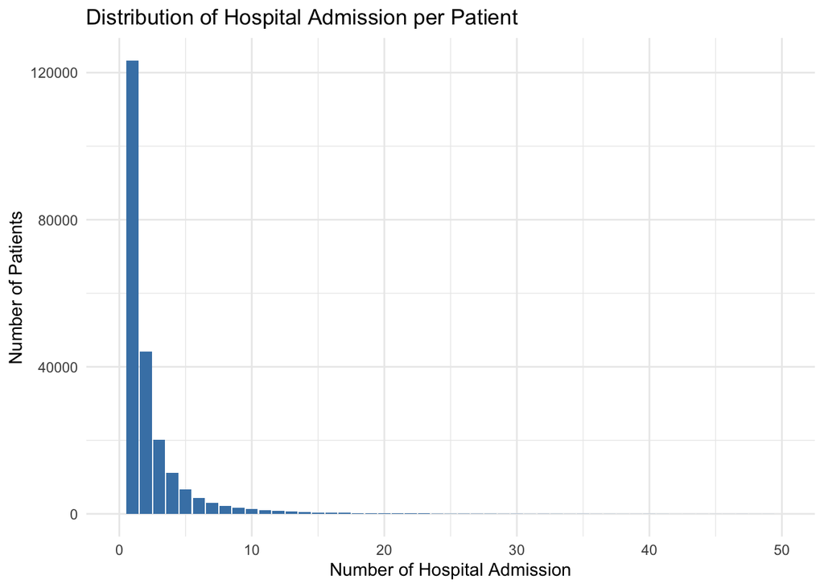

```r
### number of admissions per patient
hosp_admission_counts <- admissions_tble %>%
  group_by(subject_id) %>%
  summarise(num_stays = n())

hosp_admission_distribution <- hosp_admission_counts %>%
  group_by(num_stays) %>%
  summarise(frequency = n())

ggplot(hosp_admission_distribution, aes(x = num_stays, y = frequency)) +
  xlim(0, 50)+
  geom_bar(stat = "identity", fill = "steelblue") +
  labs(
    title = "Distribution of Hospital Admission per Patient",
    x = "Number of Hospital Admission",
    y = "Number of Patients"
  ) +
  theme_minimal()
```

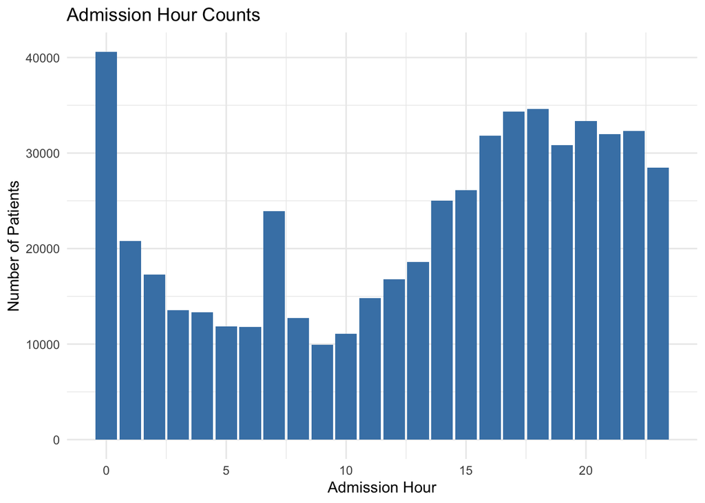

```r
### admission hour (anything unusual?)
admission_hour <- admissions_tble %>%
  mutate(admit_hour = hour(admittime))

admission_hour_distribution <- admission_hour %>%
  group_by(admit_hour) %>%
  summarise(frequency = n())

ggplot(admission_hour_distribution, aes(x = admit_hour, y = frequency)) +
  geom_bar(stat = "identity", fill = "steelblue") +
             labs(title = "Admission Hour Counts",
                  x = "Admission Hour",
                  y = "Number of Patients"
                  ) +
  theme_minimal()
```

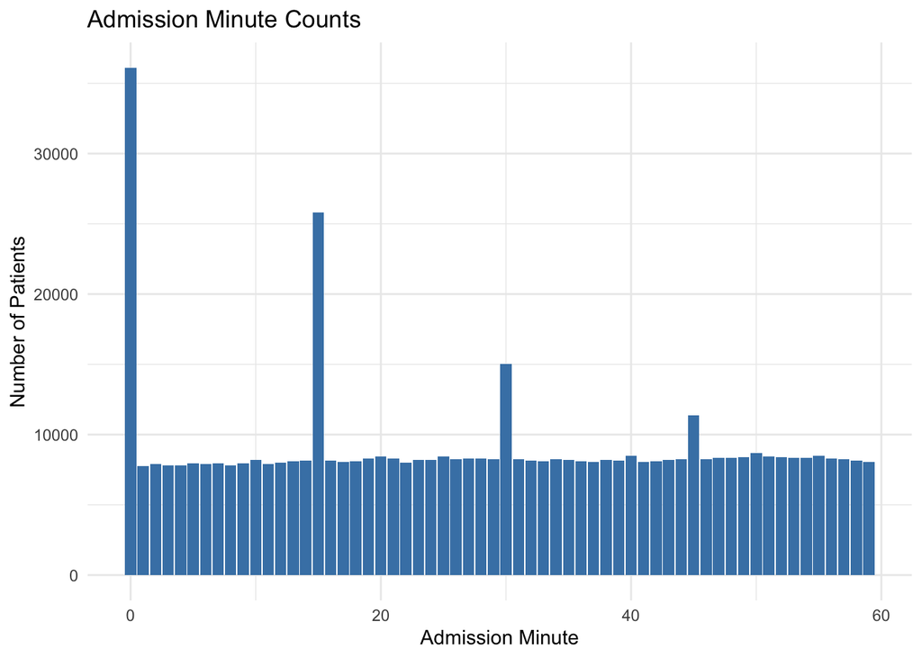

```r
### admission minute (anything unusual?)
admission_minute <- admissions_tble %>%
  mutate(admit_minute = minute(admittime))

admission_minute_distribution <- admission_minute %>%
  group_by(admit_minute) %>%
  summarise(frequency = n())

ggplot(admission_minute_distribution, aes(x = admit_minute, y = frequency)) +
  geom_bar(stat = "identity", fill = "steelblue") +
             labs(title = "Admission Minute Counts",
                  x = "Admission Minute",
                  y = "Number of Patients"
                  ) +
  theme_minimal()
```

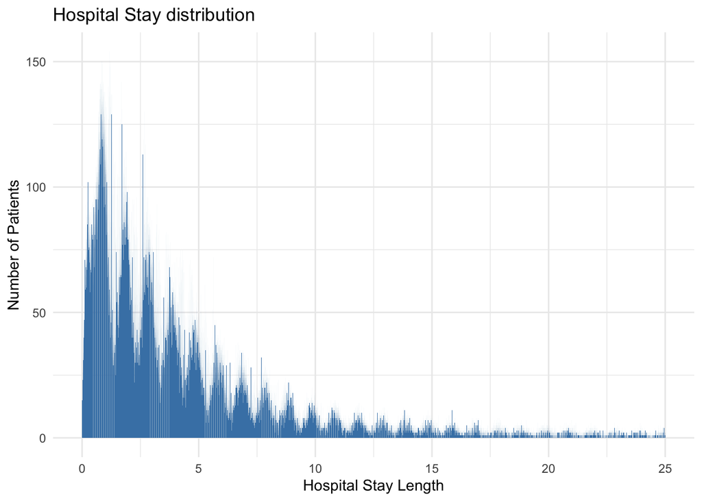

```r
### length of hospital stay (from admission to discharge) (anything unusual?)
hospital_stay <- admissions_tble |>
      mutate(length_of_stay = as.numeric(difftime(dischtime,
                                                  admittime,
                                                  units = "days")))

hosp_stay_distribution <- hospital_stay |>
  group_by(length_of_stay) |>
  summarise(frequency = n())

ggplot(hosp_stay_distribution, aes(x = length_of_stay, y = frequency)) +
  xlim(0, 25)+
  geom_bar(stat = "identity", fill = "steelblue") +
             labs(title = "Hospital Stay distribution",
                  x = "Hospital Stay Length",
                  y = "Number of Patients"
                  ) +
  theme_minimal()
```

## Q4. `patients` data

Patient information is available in `patients.csv.gz`. See https://mimic.mit.edu/docs/iv/modules/hosp/patients/ for details of each field in this file. The first 10 lines are

```bash
zcat < ~/mimic/hosp/patients.csv.gz | head
```

```
subject_id,gender,anchor_age,anchor_year,anchor_year_group,dod
10000032,F,52,2180,2014 - 2016,2180-09-09
10000048,F,23,2126,2008 - 2010,
10000058,F,33,2168,2020 - 2022,
10000068,F,19,2160,2008 - 2010,
10000084,M,72,2160,2017 - 2019,2161-02-13
10000102,F,27,2136,2008 - 2010,
10000108,M,25,2163,2014 - 2016,
10000115,M,24,2154,2017 - 2019,
10000117,F,48,2174,2008 - 2010,
```

### Q4.1 Ingestion

Import `patients.csv.gz` (https://mimic.mit.edu/docs/iv/modules/hosp/patients/) as a tibble `patients_tble`.

```r
patients_tble <- read_csv("~/mimic/hosp/patients.csv.gz")
```

### Q4.2 Summary and visualization

Summarize variables `gender` and `anchor_age` by graphics, and explain any patterns you see.

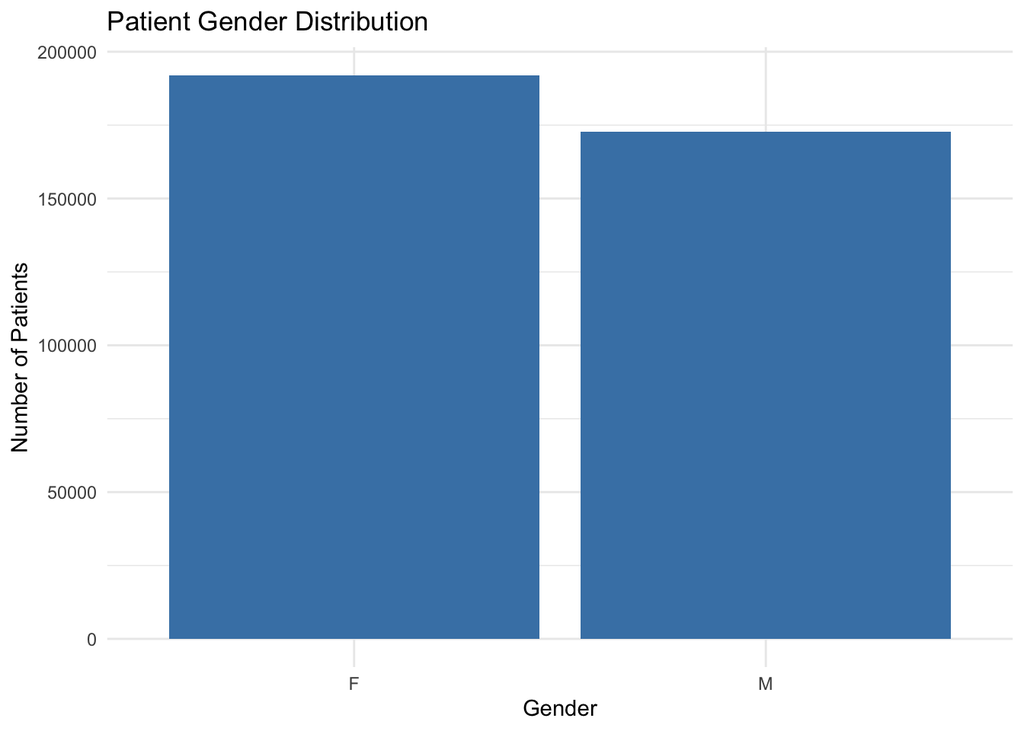

```r
### gender
gender_dist <- patients_tble |>
  group_by(gender) |>
  summarise(frequency = n())

age_dist <- patients_tble |>
  group_by(anchor_age) |>
  summarise(frequency = n())

ggplot(gender_dist, aes(x = gender, y = frequency)) +
  geom_bar(stat = "identity", fill = "steelblue") +
             labs(title = "Patient Gender Distribution",
                  x = "Gender",
                  y = "Number of Patients"
                  ) +
  theme_minimal()
```

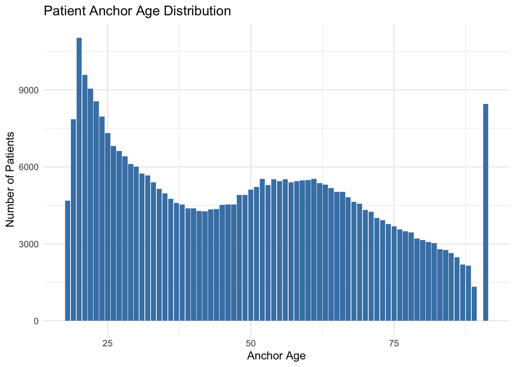

```r
ggplot(age_dist, aes(x = anchor_age, y = frequency)) +
  geom_bar(stat = "identity", fill = "steelblue") +
             labs(title = "Patient Anchor Age Distribution",
                  x = "Anchor Age",
                  y = "Number of Patients"
                  ) +
  theme_minimal()
```

## Q5. Lab results

`labevents.csv.gz` (https://mimic.mit.edu/docs/iv/modules/hosp/labevents/) contains all laboratory measurements for patients. The first 10 lines are

```bash
zcat < ~/mimic/hosp/labevents.csv.gz | head
```

```
labevent_id,subject_id,hadm_id,specimen_id,itemid,order_provider_id,charttime,storetime,value,valuenum,valueuom,ref_range_lower,ref_range_upper,flag,priority,comments
1,10000032,,2704548,50931,P69FQC,2180-03-23 11:51:00,2180-03-23 15:56:00,___,95,mg/dL,70,100,,ROUTINE,"IF FASTING, 70-100 NORMAL, >125 PROVISIONAL DIABETES."
2,10000032,,36092842,51071,P69FQC,2180-03-23 11:51:00,2180-03-23 16:00:00,NEG,,,,,,ROUTINE,
3,10000032,,36092842,51074,P69FQC,2180-03-23 11:51:00,2180-03-23 16:00:00,NEG,,,,,,ROUTINE,
4,10000032,,36092842,51075,P69FQC,2180-03-23 11:51:00,2180-03-23 16:00:00,NEG,,,,,,ROUTINE,"BENZODIAZEPINE IMMUNOASSAY SCREEN DOES NOT DETECT SOME DRUGS,;INCLUDING LORAZEPAM, CLONAZEPAM, AND FLUNITRAZEPAM."
5,10000032,,36092842,51079,P69FQC,2180-03-23 11:51:00,2180-03-23 16:00:00,NEG,,,,,,ROUTINE,
6,10000032,,36092842,51087,P69FQC,2180-03-23 11:51:00,,,,,,,,ROUTINE,RANDOM.
7,10000032,,36092842,51089,P69FQC,2180-03-23 11:51:00,2180-03-23 16:15:00,,,,,,,ROUTINE,PRESUMPTIVELY POSITIVE.
8,10000032,,36092842,51090,P69FQC,2180-03-23 11:51:00,2180-03-23 16:00:00,NEG,,,,,,ROUTINE,METHADONE ASSAY DETECTS ONLY METHADONE (NOT OTHER OPIATES/OPIOIDS).
9,10000032,,36092842,51092,P69FQC,2180-03-23 11:51:00,2180-03-23 16:00:00,NEG,,,,,,ROUTINE,"OPIATE IMMUNOASSAY SCREEN DOES NOT DETECT SYNTHETIC OPIOIDS;SUCH AS METHADONE, OXYCODONE, FENTANYL, BUPRENORPHINE, TRAMADOL,;NALOXONE, MEPERIDINE.  SEE ONLINE LAB MANUAL FOR DETAILS."
```

`d_labitems.csv.gz` (https://mimic.mit.edu/docs/iv/modules/hosp/d_labitems/) is the dictionary of lab measurements.

```bash
zcat < ~/mimic/hosp/d_labitems.csv.gz | head
```

```
itemid,label,fluid,category
50801,Alveolar-arterial Gradient,Blood,Blood Gas
50802,Base Excess,Blood,Blood Gas
50803,"Calculated Bicarbonate, Whole Blood",Blood,Blood Gas
50804,Calculated Total CO2,Blood,Blood Gas
50805,Carboxyhemoglobin,Blood,Blood Gas
50806,"Chloride, Whole Blood",Blood,Blood Gas
50808,Free Calcium,Blood,Blood Gas
50809,Glucose,Blood,Blood Gas
50810,"Hematocrit, Calculated",Blood,Blood Gas
```

We are interested in the lab measurements of creatinine (50912), potassium (50971), sodium (50983), chloride (50902), bicarbonate (50882), hematocrit (51221), white blood cell count (51301), and glucose (50931). Retrieve a subset of `labevents.csv.gz` that only containing these items for the patients in `icustays_tble`. Further restrict to the last available measurement (by `storetime`) before the ICU stay. The final `labevents_tble` should have one row per ICU stay and columns for each lab measurement.

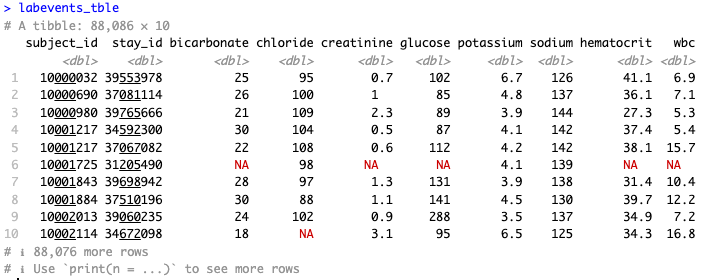

Hint: Use the Parquet format you generated in Homework 2. For reproducibility, make `labevents_pq` folder available at the current working directory `hw3`, for example, by a symbolic link. get the most recent lab result of each patients for each icu stay

**Solution:** My work is shown below.

```r
# I followed Dr.Zhou's instruction during lecture for this question
# create dictionary table
dlabitems_tble <- read.csv("~/mimic/hosp/d_labitems.csv.gz") |>
  filter(itemid %in% c(
    50912, 50971, 50983, 50902, 50882, 51221, 51301, 50931)) |>
  mutate(itemid = as.integer(itemid)) |>
  print()
```

```
  itemid             label fluid   category
1  50882       Bicarbonate Blood  Chemistry
2  50902          Chloride Blood  Chemistry
3  50912        Creatinine Blood  Chemistry
4  50931           Glucose Blood  Chemistry
5  50971         Potassium Blood  Chemistry
6  50983            Sodium Blood  Chemistry
7  51221        Hematocrit Blood Hematology
8  51301 White Blood Cells Blood Hematology
```

```r
# data wrangling step
labevents_tble <- open_dataset("labevents_parquet", format = "parquet") |>
  to_duckdb() |>
  select(subject_id, itemid, storetime, valuenum) |>
  filter(itemid %in% dlabitems_tble$itemid) |>
  left_join(
    select(icustays_tble, subject_id, stay_id, intime),
    by=c("subject_id"),
    #copy=TRUE copies the r table into duckdb table to make them mergeable
    copy = TRUE )|>
  filter(storetime < intime) |>
  group_by(subject_id, stay_id, itemid) |>
  slice_max(storetime, n = 1) |>
  select(-storetime, -intime) |>
  ungroup() |>
  pivot_wider(names_from = itemid, values_from = valuenum) |>
  rename_at (
    vars(as.character(dlabitems_tble$itemid)),
    ~str_to_lower(dlabitems_tble$label)
  ) |>
  rename(wbc = `white blood cells`) |>
  show_query() |>
  collect() |>
  arrange(subject_id, stay_id) |>
  relocate(subject_id, stay_id, chloride, hematocrit, bicarbonate, glucose, potassium, sodium, hematocrit, wbc) |>
  print(width = Inf)
```

```
<SQL>
SELECT
  subject_id,
  stay_id,
  MAX(CASE WHEN (itemid = 51301.0) THEN valuenum END) AS wbc,
  MAX(CASE WHEN (itemid = 50971.0) THEN valuenum END) AS potassium,
  MAX(CASE WHEN (itemid = 50912.0) THEN valuenum END) AS creatinine,
  MAX(CASE WHEN (itemid = 50882.0) THEN valuenum END) AS bicarbonate,
  MAX(CASE WHEN (itemid = 50931.0) THEN valuenum END) AS glucose,
  MAX(CASE WHEN (itemid = 51221.0) THEN valuenum END) AS hematocrit,
  MAX(CASE WHEN (itemid = 50902.0) THEN valuenum END) AS chloride,
  MAX(CASE WHEN (itemid = 50983.0) THEN valuenum END) AS sodium
FROM (
  SELECT subject_id, itemid, valuenum, stay_id
  FROM (
    SELECT
      q01.*,
      RANK() OVER (PARTITION BY subject_id, stay_id, itemid ORDER BY storetime DESC) AS col01
    FROM (
      SELECT LHS.*, stay_id, intime
      FROM (
        SELECT subject_id, itemid, storetime, valuenum
        FROM arrow_001
        WHERE (itemid IN (50882, 50902, 50912, 50931, 50971, 50983, 51221, 51301))
      ) LHS
      LEFT JOIN dbplyr_aQeEtDfZFO
        ON (LHS.subject_id = dbplyr_aQeEtDfZFO.subject_id)
    ) q01
    WHERE (storetime < intime)
  ) q01
  WHERE (col01 <= 1)
) q01
GROUP BY subject_id, stay_id
# A tibble: 88,086 × 10
   subject_id  stay_id chloride hematocrit bicarbonate glucose potassium sodium
        <dbl>    <dbl>    <dbl>      <dbl>       <dbl>   <dbl>     <dbl>  <dbl>
 1   10000032 39553978       95       41.1          25     102       6.7    126
 2   10000690 37081114      100       36.1          26      85       4.8    137
 3   10000980 39765666      109       27.3          21      89       3.9    144
 4   10001217 34592300      104       37.4          30      87       4.1    142
 5   10001217 37067082      108       38.1          22     112       4.2    142
 6   10001725 31205490       98       NA            NA      NA       4.1    139
 7   10001843 39698942       97       31.4          28     131       3.9    138
 8   10001884 37510196       88       39.7          30     141       4.5    130
 9   10002013 39060235      102       34.9          24     288       3.5    137
10   10002114 34672098       NA       34.3          18      95       6.5    125
     wbc creatinine
   <dbl>      <dbl>
 1   6.9        0.7
 2   7.1        1
 3   5.3        2.3
 4   5.4        0.5
 5  15.7        0.6
 6  NA         NA
 7  10.4        1.3
 8  12.2        1.1
 9   7.2        0.9
10  16.8        3.1
# ℹ 88,076 more rows
```

## Q6. Vitals from charted events

`chartevents.csv.gz` (https://mimic.mit.edu/docs/iv/modules/icu/chartevents/) contains all the charted data available for a patient. During their ICU stay, the primary repository of a patient’s information is their electronic chart. The `itemid` variable indicates a single measurement type in the database. The `value` variable is the value measured for `itemid`. The first 10 lines of `chartevents.csv.gz` are

```bash
zcat < ~/mimic/icu/chartevents.csv.gz | head
```

```
subject_id,hadm_id,stay_id,caregiver_id,charttime,storetime,itemid,value,valuenum,valueuom,warning
10000032,29079034,39553978,18704,2180-07-23 12:36:00,2180-07-23 14:45:00,226512,39.4,39.4,kg,0
10000032,29079034,39553978,18704,2180-07-23 12:36:00,2180-07-23 14:45:00,226707,60,60,Inch,0
10000032,29079034,39553978,18704,2180-07-23 12:36:00,2180-07-23 14:45:00,226730,152,152,cm,0
10000032,29079034,39553978,18704,2180-07-23 14:00:00,2180-07-23 14:18:00,220048,SR (Sinus Rhythm),,,0
10000032,29079034,39553978,18704,2180-07-23 14:00:00,2180-07-23 14:18:00,224642,Oral,,,0
10000032,29079034,39553978,18704,2180-07-23 14:00:00,2180-07-23 14:18:00,224650,None,,,0
10000032,29079034,39553978,18704,2180-07-23 14:00:00,2180-07-23 14:20:00,223761,98.7,98.7,°F,0
10000032,29079034,39553978,18704,2180-07-23 14:11:00,2180-07-23 14:17:00,220179,84,84,mmHg,0
10000032,29079034,39553978,18704,2180-07-23 14:11:00,2180-07-23 14:17:00,220180,48,48,mmHg,0
```

`d_items.csv.gz` (https://mimic.mit.edu/docs/iv/modules/icu/d_items/) is the dictionary for the `itemid` in `chartevents.csv.gz`.

```bash
zcat < ~/mimic/icu/d_items.csv.gz | head
```

```
itemid,label,abbreviation,linksto,category,unitname,param_type,lownormalvalue,highnormalvalue
220001,Problem List,Problem List,chartevents,General,,Text,,
220003,ICU Admission date,ICU Admission date,datetimeevents,ADT,,Date and time,,
220045,Heart Rate,HR,chartevents,Routine Vital Signs,bpm,Numeric,,
220046,Heart rate Alarm - High,HR Alarm - High,chartevents,Alarms,bpm,Numeric,,
220047,Heart Rate Alarm - Low,HR Alarm - Low,chartevents,Alarms,bpm,Numeric,,
220048,Heart Rhythm,Heart Rhythm,chartevents,Routine Vital Signs,,Text,,
220050,Arterial Blood Pressure systolic,ABPs,chartevents,Routine Vital Signs,mmHg,Numeric,90,140
220051,Arterial Blood Pressure diastolic,ABPd,chartevents,Routine Vital Signs,mmHg,Numeric,60,90
220052,Arterial Blood Pressure mean,ABPm,chartevents,Routine Vital Signs,mmHg,Numeric,,
```

We are interested in the vitals for ICU patients: heart rate (220045), systolic non-invasive blood pressure (220179), diastolic non-invasive blood pressure (220180), body temperature in Fahrenheit (223761), and respiratory rate (220210). Retrieve a subset of `chartevents.csv.gz` only containing these items for the patients in `icustays_tble`. Further restrict to the first vital measurement within the ICU stay. The final `chartevents_tble` should have one row per ICU stay and columns for each vital measurement.

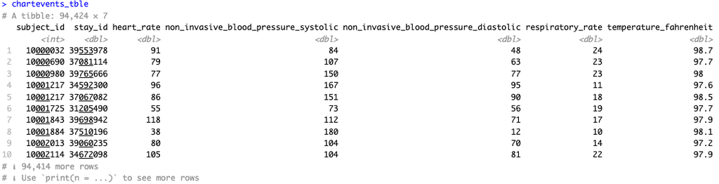

**Solution:** My work is shown below.

```r
#take the average of the value at all storetime

dchartitems_tble <- read.csv("~/mimic/icu/d_items.csv.gz") |>
  filter(itemid %in% c(
    220045, 220179, 220180, 223761, 220210)) |>
  mutate(itemid = as.integer(itemid)) |>
  print()
```

```
  itemid                                 label  abbreviation     linksto
1 220045                            Heart Rate            HR chartevents
2 220179  Non Invasive Blood Pressure systolic          NBPs chartevents
3 220180 Non Invasive Blood Pressure diastolic          NBPd chartevents
4 220210                      Respiratory Rate            RR chartevents
5 223761                Temperature Fahrenheit Temperature F chartevents
             category unitname param_type lownormalvalue highnormalvalue
1 Routine Vital Signs      bpm    Numeric             NA              NA
2 Routine Vital Signs     mmHg    Numeric             NA              NA
3 Routine Vital Signs     mmHg    Numeric             NA              NA
4         Respiratory insp/min    Numeric             NA              NA
5 Routine Vital Signs       °F    Numeric             NA              NA
```

```r
chartevents_tble <- open_dataset("chartevents_parquet", format = "parquet") |>
  to_duckdb() |>
  select(subject_id, itemid, storetime, valuenum) |>
  filter(itemid %in% dchartitems_tble$itemid) |>
  left_join(
    select(icustays_tble, subject_id, stay_id),
    by=c("subject_id"),
    #copy=TRUE copies the r table into duckdb table to make them mergeable
    copy = TRUE )|>
  group_by(subject_id, stay_id, itemid) |>
  # i forgot if Dr. Zhou want us to take average of the mean value or use the first stored value. but here is the case when taking the mean:
  #summarise(mean_valuenum = mean(valuenum, na.rm = TRUE), .groups = "drop") |>
  slice_min(storetime, n = 1) |>
  select(-storetime) |>
  ungroup() |>
  pivot_wider(names_from = itemid, values_from = valuenum) |>
  rename_at (
    vars(as.character(dchartitems_tble$itemid)),
    ~str_to_lower(dchartitems_tble$label)
  ) |>
  # # # show_query() |>
  collect() |>
  arrange(subject_id, stay_id) |>
  relocate(subject_id, stay_id, `heart rate`,
           `non invasive blood pressure diastolic`,
           `non invasive blood pressure systolic`,
           `respiratory rate`, `temperature fahrenheit`) |>
  print(width = Inf)
```

```
# A tibble: 94,458 × 7
   subject_id  stay_id `heart rate` `non invasive blood pressure diastolic`
        <dbl>    <dbl>        <dbl>                                   <dbl>
 1   10000032 39553978           91                                      48
 2   10000690 37081114           80                                      63
 3   10000980 39765666           77                                     127
 4   10001217 34592300           86                                      90
 5   10001217 37067082           86                                      90
 6   10001725 31205490           86                                      56
 7   10001843 39698942          131                                      85
 8   10001884 37510196           60                                      49
 9   10002013 39060235           80                                      70
10   10002114 34672098          111                                      80
   `non invasive blood pressure systolic` `respiratory rate`
                                    <dbl>              <dbl>
```

[output cut: 23 more lines]

## Q7. Putting things together

Let us create a tibble `mimic_icu_cohort` for all ICU stays, where rows are all ICU stays of adults (age at `intime` >= 18) and columns contain at least following variables

- all variables in `icustays_tble`
- all variables in `admissions_tble`
- all variables in `patients_tble`
- the last lab measurements before the ICU stay in `labevents_tble`
- the first vital measurements during the ICU stay in `chartevents_tble`

The final `mimic_icu_cohort` should have one row per ICU stay and columns for each variable.

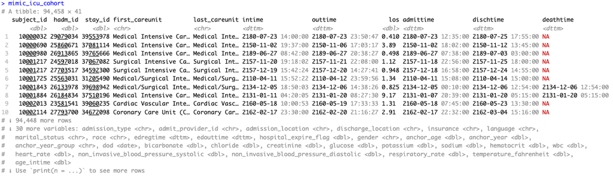

**Solution:** My work is shown below.

```r
#according to mimic documentation online, age of a patient = hospital admission time - anchor_year + anchor_age
mimic_icu_cohort <- patients_tble |>
  left_join(icustays_tble, by = c("subject_id")) |>
  mutate(age_at_intime = year(intime) - anchor_year + anchor_age) |>
  filter(age_at_intime >=18) |>
  left_join(admissions_tble, by = c("subject_id","hadm_id"))

first_vitals <- chartevents_tble |>
  group_by(subject_id, stay_id) |>
  slice_min(stay_id, n = 1) |>  # Get the first recorded value
  ungroup()

#  Summarize LAST lab values BEFORE ICU stay
last_labs <- labevents_tble |>
  group_by(subject_id, stay_id) |>
  slice_max(stay_id, n = 1) |>  # Get the last recorded value before ICU
  ungroup()

#  JOIN summarized tables to mimic_icu_cohort
mimic_icu_cohort <- mimic_icu_cohort |>
  left_join(first_vitals, by = c("subject_id", "stay_id")) |>
  left_join(last_labs, by = c("subject_id", "stay_id"))

# Check final structure
print(mimic_icu_cohort)
```

```
# A tibble: 94,458 × 41
   subject_id gender anchor_age anchor_year anchor_year_group dod        hadm_id
        <dbl> <chr>       <dbl>       <dbl> <chr>             <date>       <dbl>
 1   10000032 F              52        2180 2014 - 2016       2180-09-09  2.91e7
 2   10000690 F              86        2150 2008 - 2010       2152-01-30  2.59e7
 3   10000980 F              73        2186 2008 - 2010       2193-08-26  2.69e7
 4   10001217 F              55        2157 2011 - 2013       NA          2.46e7
 5   10001217 F              55        2157 2011 - 2013       NA          2.77e7
 6   10001725 F              46        2110 2011 - 2013       NA          2.56e7
 7   10001843 M              73        2131 2017 - 2019       2134-12-06  2.61e7
 8   10001884 F              68        2122 2008 - 2010       2131-01-20  2.62e7
 9   10002013 F              53        2156 2008 - 2010       NA          2.36e7
10   10002114 M              56        2162 2020 - 2022       2162-12-11  2.78e7
# ℹ 94,448 more rows
# ℹ 34 more variables: stay_id <dbl>, first_careunit <chr>,
#   last_careunit <chr>, intime <dttm>, outtime <dttm>, los <dbl>,
#   age_at_intime <dbl>, admittime <dttm>, dischtime <dttm>, deathtime <dttm>,
#   admission_type <chr>, admit_provider_id <chr>, admission_location <chr>,
#   discharge_location <chr>, insurance <chr>, language <chr>,
#   marital_status <chr>, race <chr>, edregtime <dttm>, edouttime <dttm>, …
```

## Q8. Exploratory data analysis (EDA)

Summarize the following information about the ICU stay cohort `mimic_icu_cohort` using appropriate numerics or graphs:

- Length of ICU stay `los` vs demographic variables (race, insurance, marital_status, gender, age at intime)
- Length of ICU stay `los` vs the last available lab measurements before ICU stay
- Length of ICU stay `los` vs the first vital measurements within the ICU stay
- Length of ICU stay `los` vs first ICU unit

**Solution:** I choose to do a numeric summary for the first 3 and a ggplot for the last one. The results are shown below.

```r
demographics <- c("race", "insurance", "marital_status", "gender", "age_at_intime")
for (i in demographics) {
  summary_table <- mimic_icu_cohort |>
  group_by(.data[[i]]) |>
  summarise(mean_los = mean(los, na.rm = TRUE),
            median_los = median(los, na.rm = TRUE)) |>
  arrange(desc(mean_los)) |>
    print()
}
```

```
# A tibble: 33 × 3
   race                          mean_los median_los
   <chr>                            <dbl>      <dbl>
 1 UNABLE TO OBTAIN                  4.72       2.36
 2 UNKNOWN                           4.52       2.27
 3 ASIAN - KOREAN                    4.44       2.25
 4 PORTUGUESE                        4.41       2.14
 5 BLACK/CARIBBEAN ISLAND            4.34       2.04
 6 AMERICAN INDIAN/ALASKA NATIVE     4.31       2.08
 7 HISPANIC/LATINO - COLUMBIAN       4.10       1.80
 8 HISPANIC/LATINO - DOMINICAN       4.10       2.13
 9 ASIAN - ASIAN INDIAN              4.08       1.90
10 BLACK/AFRICAN                     4.01       2.08
# ℹ 23 more rows
# A tibble: 6 × 3
  insurance mean_los median_los
  <chr>        <dbl>      <dbl>
1 No charge     3.87       2.60
2 Medicaid      3.79       1.90
3 Private       3.64       1.88
4 Medicare      3.60       2.03
5 Other         3.39       1.86
6 <NA>          3.21       1.65
# A tibble: 5 × 3
  marital_status mean_los median_los
  <chr>             <dbl>      <dbl>
1 <NA>               4.64       2.33
2 SINGLE             3.59       1.91
3 MARRIED            3.59       1.97
4 DIVORCED           3.58       1.95
5 WIDOWED            3.18       1.93
# A tibble: 2 × 3
  gender mean_los median_los
  <chr>     <dbl>      <dbl>
1 M          3.72       1.98
2 F          3.51       1.94
# A tibble: 86 × 3
   age_at_intime mean_los median_los
           <dbl>    <dbl>      <dbl>
 1            27     4.67       1.98
 2            58     4.09       2.02
 3            43     4.09       1.84
 4            32     4.08       1.83
 5            42     4.07       1.94
 6            47     4.02       2.04
 7            44     3.97       1.89
 8            67     3.97       2.03
 9            30     3.93       1.82
10            70     3.90       2.00
# ℹ 76 more rows
```

```r
lab_measurements <- names(labevents_tble)[-c(1,2)]
for (i in lab_measurements) {
  summary_table <- mimic_icu_cohort |>
  group_by(.data[[i]]) |>
  summarise(mean_los = mean(los, na.rm = TRUE),
            median_los = median(los, na.rm = TRUE)) |>
  arrange(desc(mean_los)) |>
    print()
}
```

```
# A tibble: 86 × 3
   chloride mean_los median_los
      <dbl>    <dbl>      <dbl>
 1       64     7.87       3.92
 2       66     6.29       4.77
 3       71     5.86       2.37
 4      124     5.47       3.21
 5      117     4.82       2.14
 6       NA     4.69       2.23
 7       88     4.60       2.20
 8      128     4.59       3.19
 9      123     4.43       2.71
10       73     4.38       3.72
# ℹ 76 more rows
# A tibble: 526 × 3
```

[output cut: 97 more lines]

```r
vital_measurements <- names(chartevents_tble)[-c(1,2)]
for (i in vital_measurements) {
  summary_table <- mimic_icu_cohort |>
  group_by(.data[[i]]) |>
  summarise(mean_los = mean(los, na.rm = TRUE),
            median_los = median(los, na.rm = TRUE)) |>
  arrange(desc(mean_los)) |>
    print()
}
```

```
# A tibble: 173 × 3
   `heart rate` mean_los median_los
          <dbl>    <dbl>      <dbl>
 1          191    30.9       30.9
 2          167    10.7        6.75
 3          173     8.55       5.05
 4          180     6.27       2.58
 5          160     5.94       2.30
 6          179     5.94       2.91
 7          181     5.90       5.90
 8          171     5.75       1.68
 9          166     5.71       3.27
10          174     5.57       5.64
# ℹ 163 more rows
# A tibble: 190 × 3
```

[output cut: 55 more lines]

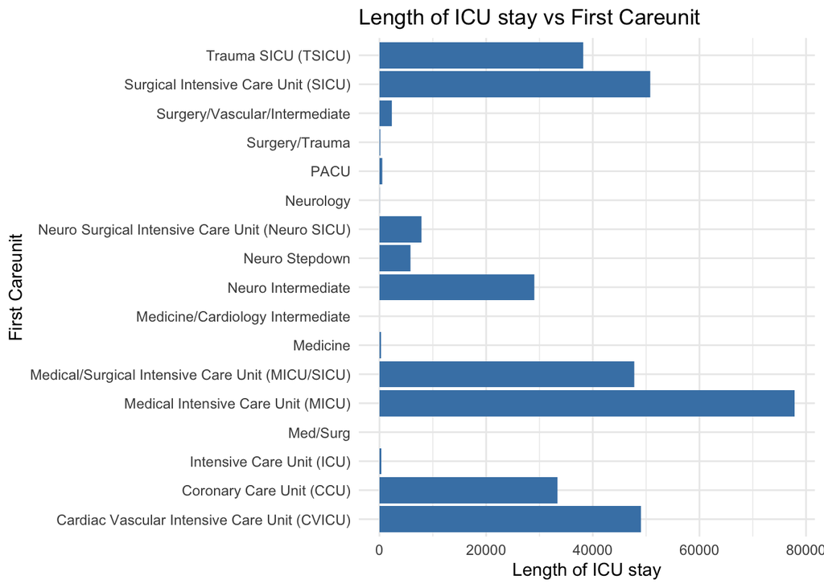

```r
ggplot(mimic_icu_cohort, aes(x=first_careunit, y=los)) +
  geom_bar(stat = "identity", fill = "steelblue") +
   labs(
    title = "Length of ICU stay vs First Careunit",
    x = "First Careunit",
    y = "Length of ICU stay"
  ) +
  theme_minimal()+
  coord_flip()
```